## Introduction

The sinking of the RMS Titanic occurred on April 15, 1912 and was considered to be one of the most deadly shipwrecks in the history. The major cause of the incident was due to its collision with an iceberg, which led to 1502 deaths out of 2224 passengers and ship crews. There are several reason why the shipwreck ended up with such massive loss of life, and one of the reason was lack of lifeboats.

It appears that the chance of survival in this kind of incident depends heavily on luck, but it is certain that some group of people were more likely to survive. For example, the famous phrase “Women and children first” increases the chance for women and children to survive in such incident. This analysis mainly focuses on applying machine learning algorithms in R to predict the survival of certain passengers.

## The Datasets

All datasets used in this analysis are pertain to Kaggle, the followings are the links to the data sets:

[Train](https://www.kaggle.com/c/titanic/download/train.csv)

[Test](https://www.kaggle.com/c/titanic/download/test.csv)

The Train dataset is for building machine learning models and then apply these models on Test dataset.

## Examing the Dataset

Now begin with loading some libraries for the models that will be used(Packages must be installed first)

```r
library(rpart)
library(rattle)
library(rpart.plot)
library(RColorBrewer)
library(randomForest)
```

Load the two datasets using read.csv() function and use str() function to examine the basic structures of the Train dataset. Simple facts can be observed for some columns:

*There are 891 observations and 12 columns

*“Survived” is the survival of passenger(1 = Yes, 0 = No)

*“Pclass” is the Passenger Class(1 = 1st, 2 = 2nd, 3 = 3rd)

*“sibsp” is the number of silblings and spouses

*“parch” is the number of parents and children

*“Ticket” is the ticket number, not unique since there are only 681 levels for 891 observations

*“embarked” is the port of embarkation

```r
setwd("C:/Users/Andy/Desktop/Titanic")
train = read.csv("train.csv", header = TRUE)
test = read.csv("test.csv", header = TRUE)
str(train)
```

```
## 'data.frame':    891 obs. of  12 variables:
##  $ PassengerId: int  1 2 3 4 5 6 7 8 9 10 ...
##  $ Survived   : int  0 1 1 1 0 0 0 0 1 1 ...
##  $ Pclass     : int  3 1 3 1 3 3 1 3 3 2 ...
##  $ Name       : Factor w/ 891 levels "Abbing, Mr. Anthony",..: 109 191 358 277 16 559 520 629 417 581 ...
##  $ Sex        : Factor w/ 2 levels "female","male": 2 1 1 1 2 2 2 2 1 1 ...
##  $ Age        : num  22 38 26 35 35 NA 54 2 27 14 ...
##  $ SibSp      : int  1 1 0 1 0 0 0 3 0 1 ...
##  $ Parch      : int  0 0 0 0 0 0 0 1 2 0 ...
##  $ Ticket     : Factor w/ 681 levels "110152","110413",..: 524 597 670 50 473 276 86 396 345 133 ...
##  $ Fare       : num  7.25 71.28 7.92 53.1 8.05 ...
##  $ Cabin      : Factor w/ 148 levels "","A10","A14",..: 1 83 1 57 1 1 131 1 1 1 ...
##  $ Embarked   : Factor w/ 4 levels "","C","Q","S": 4 2 4 4 4 3 4 4 4 2 ...
```

The summary of “Age” shows relatively close mean and median, now treat all passengers who are younger than one year old as one year old. Quantile information indicates that half of the passengers are between 20 to 38 years old (NA excluded). The oldest passenger is 80 years old and there are 177 passengers with unknown age.

```r
summary(train$Age)
```

```
##    Min. 1st Qu.  Median    Mean 3rd Qu.    Max.    NA's
##    0.42   20.12   28.00   29.70   38.00   80.00     177
```

```r
train$Age[train$Age < 1] = 1
```

Below is a simple boxplot to provide a visualization of the spread of “Age”, it can be seen that there are a few outliers.

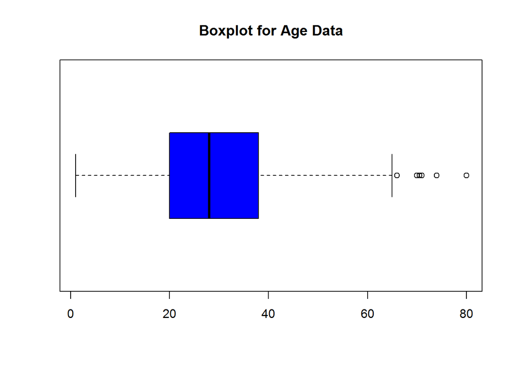

```r
boxplot(train$Age, main = "Boxplot for Age Data", horizontal = TRUE, col = 'blue')
```

Both datasets have approximately 20% of passengers with unknown age.

```r
missingAge.train = is.na(train$Age)
length(missingAge.train[missingAge.train == TRUE]) / length(train$Sex)
```

```
## [1] 0.1986532
```

```r
missingAge.test = is.na(test$Age)
length(missingAge.test[missingAge.test == TRUE]) / length(test$Sex)
```

```
## [1] 0.2057416
```

It is very obvious from the survival by gender barplot that females are much more likely to survive than males, presumably due to the idea of “Women and children first”.

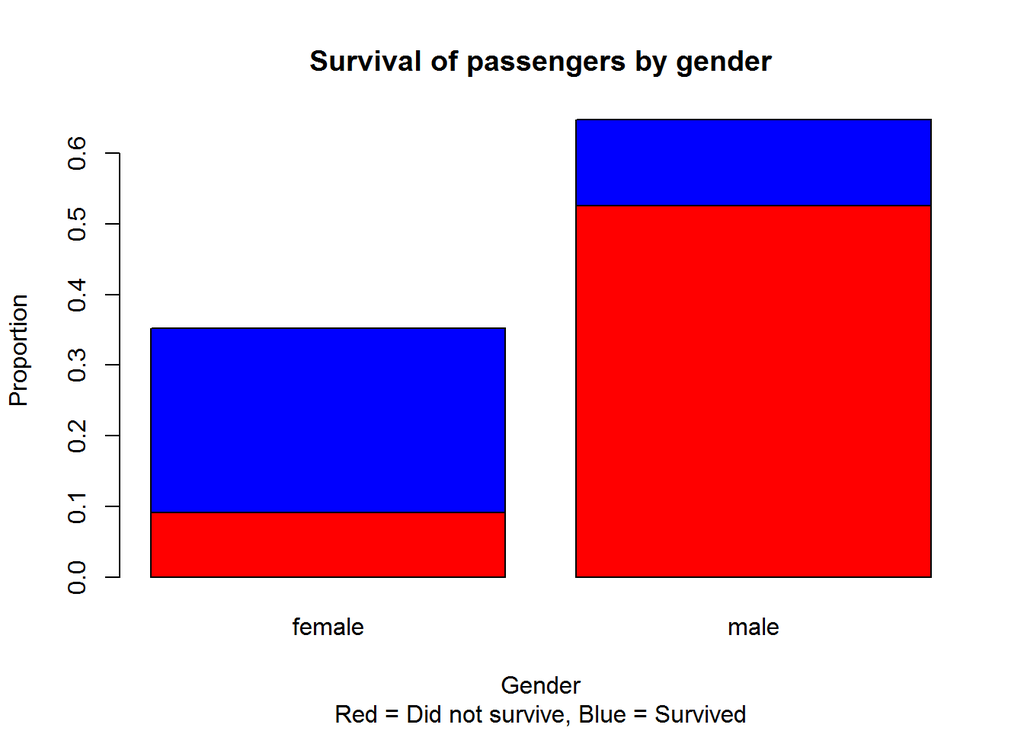

```r
table.Suv = prop.table(table(train$Survived, train$Sex))
barplot(table.Suv, main = "Survival of passengers by gender", xlab = "Gender",
        ylab = "Proportion", col = c("Red", "Blue"), sub = "Red = Did not survive, Blue = Survived")
```

[figure not shown]

```r
table.class = prop.table(table(train$Survived, train$Pclass))
barplot(table.class, main = "Survival of passengers by class", xlab = "Class", ylab = "Percentage",
        col = c("Blue", "Red"), sub = "Red = Did not survive, Blue = Survived")
```

## Cleaning the datasets

Remove variables that do not seem to help the prediction, including PassengerID, Ticket, Fare, Cabin, and Embarked.

```r
train = train[-c(1, 9:12)]
test = test[-c(8:11)]
```

Convert gender(male/female) into numerical variables(0 = male, 1 = female) in order to fit the models.

```r
train$Sex = as.character(train$Sex)
train$Sex[train$Sex == "male"] = 0
train$Sex[train$Sex == "female"] = 1
test$Sex = as.character(test$Sex)
test$Sex[test$Sex == "male"] = 0
test$Sex[test$Sex == "female"] = 1
```

```r
trainAge.mean = mean(train$Age, na.rm = TRUE)
missingAge.train = is.na(train$Age)
train$Age[missingAge.train == TRUE] = trainAge.mean
testAge.mean = mean(test$Age, na.rm = TRUE)
missingAge.test = is.na(test$Age)
test$Age[missingAge.test == TRUE] = trainAge.mean
```

```r
train$Child = 0
test$Child = 0
train$Child[train$Age <= 14] = 1
test$Child[test$Age <= 14] = 1
```

Lastly, it is possible that family size affects a passenger’s chance of survival. A new variable Family representing the total family size(Parents/children/silblings/spouses) will be added, and the minimum value it can take is 1.

```r
for(i in 1:nrow(train))
{
  parch = train$Parch[i]
  sibsp = train$SibSp[i]
  total = 1 + parch + sibsp
  train$Family[i] = total
}

for(i in 1:nrow(test))
{
  parch = test$Parch[i]
  sibsp = test$SibSp[i]
  total = 1 + parch + sibsp
  test$Family[i] = total
}

train = train[-c(6,7)]
test = test[-c(6,7)]
```

## Predictions

```r
fit1 = glm(Survived ~ Sex + Age + Pclass + Child + Family, data = train)
Prediction1 = predict(fit1, test)
Submission1 = data.frame(PassengerId = test$PassengerId, Survived = Prediction1)
Submission1$Survived[Submission1$Survived >= 0.5] = 1
Submission1$Survived[Submission1$Survived < 0.5] = 0
head(Submission1)
```

```
##   PassengerId Survived
## 1         892        0
## 2         893        1
## 3         894        0
## 4         895        0
## 5         896        1
## 6         897        0
```

[figure not shown]

```r
fit2 = rpart(Survived ~ Sex + Age + Pclass + Child + Family, data = train, method = "class")
fancyRpartPlot(fit2)
```

```r
Prediction2 = predict(fit2, test, type = "class")
Submission2 = data.frame(PassengerId = test$PassengerId, Survived = Prediction2)
head(Submission2)
```

```
##   PassengerId Survived
## 1         892        0
## 2         893        0
## 3         894        0
## 4         895        0
## 5         896        1
## 6         897        0
```